# Exercise Prediction Algorithms (PML Coursera)

08/13/2014

### Objective

Tis work will create a model to preview the quality of barbell lifts exercises performed by 6 people. Data is obtained from http://groupware.les.inf.puc-rio.br/har and contain measurements from 3 accelerometers placed on the arm, belt and forearm of each participant. The classification varies from A to E where A is the best performance. The final goal is to create a model that previews reliably 20 new observations.

Two models for predition are tested one based on Support Vector Machines and a second on Random Forest.

### Loading and cleaning data

```r
################################################################################
# Loading and Cleaning Data
#
library(caret)
setwd("L:/R/practical_ml/assignements")

training <- read.table("pml-training.csv", sep=",", header=T)
testing <- read.table("pml-testing.csv", sep=",", header=T)

# Cleaning Data NA and ""
clean_flag <- apply(training, 2, function(x) {
  sum(is.na(x)) + sum(x=="")
})

clean_training <- training[,which(clean_flag == 0)]
clean_testing <- testing[,which(clean_flag == 0)]

train_index <- createDataPartition(y = clean_training$classe, p = 0.7, list = FALSE)
training_set <- clean_training[train_index, ]
cross_validation_set <- clean_training[-train_index, ]

# Remove qualitative features (fisrt 6 columns)
remove_index <- as.integer(c(1, 2, 3, 4, 5, 6))
training_set <- training_set[, -remove_index]
testing_set <- clean_testing[, -remove_index]
```

### Support Vector Machine Model

The first model to be implemented in order to predict the new 20 occurrences from the testing set is based on SVM. Code for its contruction is presented here.

Model Construction:

```r
mytrControlsvm = trainControl(method = "cv", number = 6)
modelsvm <- train(training_set$classe ~ ., data = training_set,
                    method = "svmRadial", trControl = mytrControlsvm)
modelsvm
```

```
## Support Vector Machines with Radial Basis Function Kernel
##
## 13737 samples
##    53 predictors
##     5 classes: 'A', 'B', 'C', 'D', 'E'
##
## No pre-processing
## Resampling: Cross-Validated (6 fold)
##
## Summary of sample sizes: 11447, 11448, 11446, 11448, 11448, 11448, ...
##
## Resampling results across tuning parameters:
##
##   C    Accuracy  Kappa  Accuracy SD  Kappa SD
##   0.2  0.9       0.8    0.009        0.01
##   0.5  0.9       0.9    0.009        0.01
##   1    0.9       0.9    0.006        0.007
##
## Tuning parameter 'sigma' was held constant at a value of 0.01217
## Accuracy was used to select the optimal model using  the largest value.
## The final values used for the model were sigma = 0.01 and C = 1.
```

Prediction and accuracy:

```r
predicted_svm <- predict(modelsvm, cross_validation_set)
SampleError_svm <- sum(predicted_svm == cross_validation_set$classe)/nrow(cross_validation_set)
accuracy_svm = SampleError_svm * 100
prtext <- paste("Accuracy for SVM Model =", round(accuracy_svm,2), "%")
print(prtext)
```

```
## [1] "Accuracy for SVM Model = 93.39 %"
```

Confusion Matrix:

```r
table(predicted_svm,cross_validation_set$classe)
```

```
##
## predicted_svm    A    B    C    D    E
##             A 1642   73    3    3    0
##             B    7 1032   51    2    6
##             C   20   30  956  107   25
##             D    2    2   14  851   36
##             E    3    2    2    1 1015
```

Cost function versus Accuracy for SVM Model:

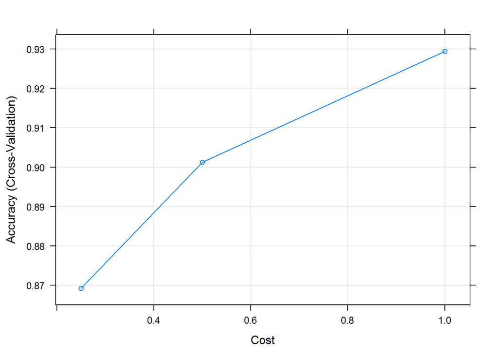

```r
plot(modelsvm)
```

Predictions:

```r
# Apply SVM Model to Testing Set
answers_svm <- predict(modelsvm, testing_set)
answers_svm
```

```
##  [1] B A A A A E D B A A B C B A E E A B B B
## Levels: A B C D E
```

### Random Forest Model (RF)

The second model to be implemented is based on RF. The code, accuracy and corresponding predictions is presented here.

```r
mytrControlrf = trainControl(method = "cv", number = 4)
modelrf <- train(training_set$classe ~ ., data = training_set,
                  method = "rf", trControl = mytrControlrf)
modelrf
```

```
## Random Forest
##
## 13737 samples
##    53 predictors
##     5 classes: 'A', 'B', 'C', 'D', 'E'
##
## No pre-processing
## Resampling: Cross-Validated (4 fold)
##
## Summary of sample sizes: 10302, 10303, 10302, 10304
##
## Resampling results across tuning parameters:
##
##   mtry  Accuracy  Kappa  Accuracy SD  Kappa SD
##   2     1         1      0.002        0.002
##   30    1         1      0.002        0.002
##   50    1         1      0.002        0.003
##
## Accuracy was used to select the optimal model using  the largest value.
## The final value used for the model was mtry = 27.
```

Prediction and accuracy:

```r
predicted_rf <- predict(modelrf, cross_validation_set)
SampleError_rf <- sum(predicted_rf == cross_validation_set$classe)/nrow(cross_validation_set)
accuracy_rf = SampleError_rf * 100
prtext <- paste("Accuracy for RF Model =", round(accuracy_rf,2), "%")
print(prtext)
```

```
## [1] "Accuracy for RF Model = 99.73 %"
```

Confusion Matrix:

```r
table(predicted_rf,cross_validation_set$classe)
```

```
##
## predicted_rf    A    B    C    D    E
##            A 1673    3    0    0    0
##            B    0 1135    6    0    0
##            C    0    1 1020    3    0
##            D    0    0    0  961    2
##            E    1    0    0    0 1080
```

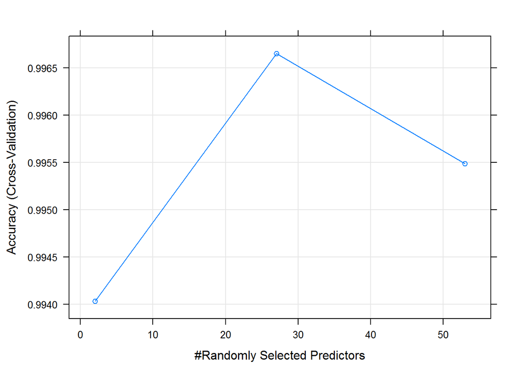

```r
plot(modelrf)
```

Predictions:

```r
# Apply RF Model to Testing Set
answers_rf <- predict(modelrf, testing_set)
answers_rf
```

```
##  [1] B A B A A E D B A A B C B A E E A B B B
## Levels: A B C D E
```

### Conclusion

Considering these results, the expected clesses for the new 20 occurrences from the testing set, correspond the predictions performed with the RF method, which are:

```r
answers_rf
```

```
##  [1] B A B A A E D B A A B C B A E E A B B B
## Levels: A B C D E
```